# Risk Factor Analysis

## Outcome Variable

**Outcome Variable:** haz

## Predictor Variables

**Intervention Variable:** fhtcm

**Adjustment Set:**

- arm
- W_mage
- W_fage
- meducyrs
- feducyrs
- W_mhtcm
- W_mwtkg
- W_mbmi
- single
- delta_W_mage
- delta_W_fage
- delta_meducyrs
- delta_feducyrs
- delta_W_mhtcm
- delta_W_mwtkg
- delta_W_mbmi
- delta_single

## Stratifying Variables

The analysis was stratified on these variable(s):

- agecat
- studyid
- country

## Data Summary

| agecat | studyid | country | fhtcm | n_cell | n | outcome_variable |
| --- | --- | --- | --- | --- | --- | --- |
| Birth | COHORTS | GUATEMALA | >=167 cm | 29 | 206 | haz |
| Birth | COHORTS | GUATEMALA | <162 cm | 121 | 206 | haz |
| Birth | COHORTS | GUATEMALA | [162-167) cm | 56 | 206 | haz |
| Birth | Keneba | GAMBIA | >=167 cm | 772 | 1167 | haz |
| Birth | Keneba | GAMBIA | <162 cm | 87 | 1167 | haz |
| Birth | Keneba | GAMBIA | [162-167) cm | 308 | 1167 | haz |
| Birth | PROBIT | BELARUS | >=167 cm | 11742 | 12535 | haz |
| Birth | PROBIT | BELARUS | <162 cm | 168 | 12535 | haz |
| Birth | PROBIT | BELARUS | [162-167) cm | 625 | 12535 | haz |
| Birth | SAS-CompFeed | INDIA | >=167 cm | 343 | 746 | haz |
| Birth | SAS-CompFeed | INDIA | <162 cm | 190 | 746 | haz |
| Birth | SAS-CompFeed | INDIA | [162-167) cm | 213 | 746 | haz |
| 6 months | COHORTS | GUATEMALA | >=167 cm | 45 | 336 | haz |
| 6 months | COHORTS | GUATEMALA | <162 cm | 197 | 336 | haz |
| 6 months | COHORTS | GUATEMALA | [162-167) cm | 94 | 336 | haz |
| 6 months | Keneba | GAMBIA | >=167 cm | 979 | 1511 | haz |
| 6 months | Keneba | GAMBIA | <162 cm | 113 | 1511 | haz |
| 6 months | Keneba | GAMBIA | [162-167) cm | 419 | 1511 | haz |
| 6 months | PROBIT | BELARUS | >=167 cm | 11146 | 11894 | haz |
| 6 months | PROBIT | BELARUS | <162 cm | 156 | 11894 | haz |
| 6 months | PROBIT | BELARUS | [162-167) cm | 592 | 11894 | haz |
| 6 months | SAS-CompFeed | INDIA | >=167 cm | 369 | 807 | haz |
| 6 months | SAS-CompFeed | INDIA | <162 cm | 194 | 807 | haz |
| 6 months | SAS-CompFeed | INDIA | [162-167) cm | 244 | 807 | haz |
| 6 months | SAS-FoodSuppl | INDIA | >=167 cm | 102 | 372 | haz |
| 6 months | SAS-FoodSuppl | INDIA | <162 cm | 148 | 372 | haz |
| 6 months | SAS-FoodSuppl | INDIA | [162-167) cm | 122 | 372 | haz |
| 24 months | COHORTS | GUATEMALA | >=167 cm | 70 | 526 | haz |
| 24 months | COHORTS | GUATEMALA | <162 cm | 307 | 526 | haz |
| 24 months | COHORTS | GUATEMALA | [162-167) cm | 149 | 526 | haz |
| 24 months | Keneba | GAMBIA | >=167 cm | 821 | 1297 | haz |
| 24 months | Keneba | GAMBIA | <162 cm | 97 | 1297 | haz |
| 24 months | Keneba | GAMBIA | [162-167) cm | 379 | 1297 | haz |
| 24 months | PROBIT | BELARUS | >=167 cm | 3445 | 3670 | haz |
| 24 months | PROBIT | BELARUS | <162 cm | 53 | 3670 | haz |
| 24 months | PROBIT | BELARUS | [162-167) cm | 172 | 3670 | haz |

The following strata were considered:

- agecat: 24 months, studyid: COHORTS, country: GUATEMALA
- agecat: 24 months, studyid: Keneba, country: GAMBIA
- agecat: 24 months, studyid: PROBIT, country: BELARUS
- agecat: 6 months, studyid: COHORTS, country: GUATEMALA
- agecat: 6 months, studyid: Keneba, country: GAMBIA
- agecat: 6 months, studyid: PROBIT, country: BELARUS
- agecat: 6 months, studyid: SAS-CompFeed, country: INDIA
- agecat: 6 months, studyid: SAS-FoodSuppl, country: INDIA
- agecat: Birth, studyid: COHORTS, country: GUATEMALA
- agecat: Birth, studyid: Keneba, country: GAMBIA
- agecat: Birth, studyid: PROBIT, country: BELARUS
- agecat: Birth, studyid: SAS-CompFeed, country: INDIA

## Methods Detail

We’re interested in the causal parameters $E[Y_a]$ for all values of $a \in \mathcal{A}$. These parameters represent the mean outcome if, possibly contrary to fact, we intervened to set all units to have $A=a$. Under the randomization and positivity assumptions, these are identified by the statistical parameters $\psi_a=E_W[E_{Y|A,W}(Y|A=a,W)]$. In addition, we’re interested in the mean of $Y$, $E[Y]$ under no intervention (the observed mean). We will estimate these parameters by using SuperLearner to fit the relevant likelihood factors – $E_{Y|A,W}(Y|A=a,W)$ and $p(A=a|W)$, and then updating our likelihood fit using a joint TMLE.

For unadjusted analyses ($W=\{\}$), initial likelihoods were estimated using Lrnr_glm to estimate the simple $E(Y|A)$ and Lrnr_mean to estimate $p(A)$. For adjusted analyses, a small library containing Lrnr_glmnet, Lrnr_xgboost, and Lrnr_mean was used.

Having estimated these parameters, we will then use the delta method to estimate relative risks and attributable risks relative to a prespecified baseline level of $A$.

# Results Detail

## Results Plots

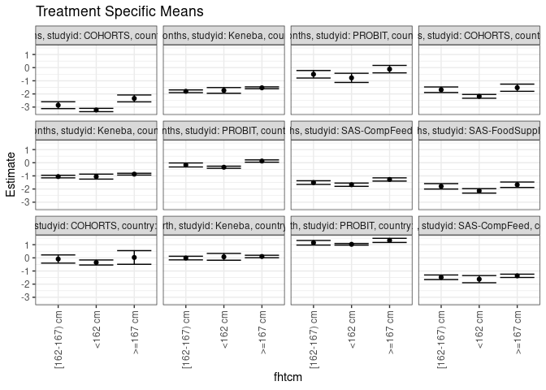

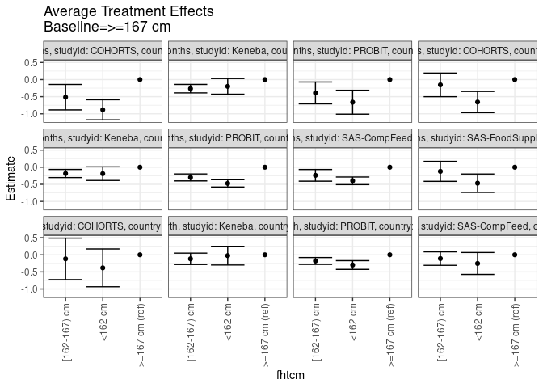

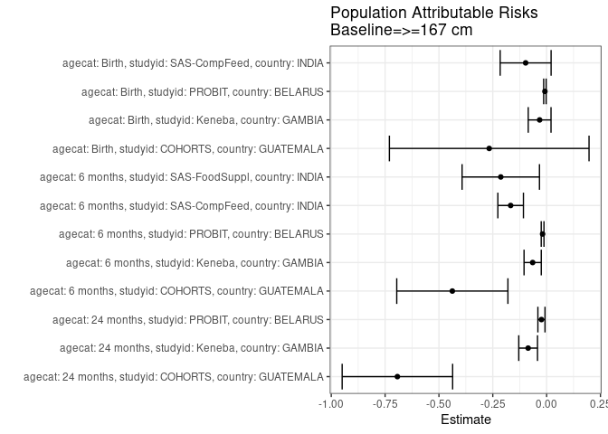

## Results Table

### Parameter: TSM

| agecat | studyid | country | intervention_level | baseline_level | estimate | ci_lower | ci_upper |
| --- | --- | --- | --- | --- | --- | --- | --- |
| Birth | COHORTS | GUATEMALA | >=167 cm | NA | 0.0298167 | -0.4892607 | 0.5488942 |
| Birth | COHORTS | GUATEMALA | <162 cm | NA | -0.3520767 | -0.5425595 | -0.1615940 |
| Birth | COHORTS | GUATEMALA | [162-167) cm | NA | -0.0893795 | -0.4003605 | 0.2216016 |
| Birth | Keneba | GAMBIA | >=167 cm | NA | 0.1026866 | 0.0074423 | 0.1979310 |
| Birth | Keneba | GAMBIA | <162 cm | NA | 0.0779262 | -0.1801092 | 0.3359616 |
| Birth | Keneba | GAMBIA | [162-167) cm | NA | -0.0153054 | -0.1522303 | 0.1216194 |
| Birth | PROBIT | BELARUS | >=167 cm | NA | 1.3283440 | 1.1711017 | 1.4855864 |
| Birth | PROBIT | BELARUS | <162 cm | NA | 1.0295782 | 0.9662140 | 1.0929424 |
| Birth | PROBIT | BELARUS | [162-167) cm | NA | 1.1478992 | 0.9725609 | 1.3232375 |
| Birth | SAS-CompFeed | INDIA | >=167 cm | NA | -1.3676281 | -1.4938315 | -1.2414247 |
| Birth | SAS-CompFeed | INDIA | <162 cm | NA | -1.6209807 | -1.8924964 | -1.3494649 |
| Birth | SAS-CompFeed | INDIA | [162-167) cm | NA | -1.4779362 | -1.6514060 | -1.3044664 |
| 6 months | COHORTS | GUATEMALA | >=167 cm | NA | -1.5274634 | -1.8001775 | -1.2547492 |
| 6 months | COHORTS | GUATEMALA | <162 cm | NA | -2.1845228 | -2.3295495 | -2.0394962 |
| 6 months | COHORTS | GUATEMALA | [162-167) cm | NA | -1.6819320 | -1.8934202 | -1.4704438 |
| 6 months | Keneba | GAMBIA | >=167 cm | NA | -0.8673098 | -0.9357839 | -0.7988357 |
| 6 months | Keneba | GAMBIA | <162 cm | NA | -1.0553426 | -1.2436882 | -0.8669970 |
| 6 months | Keneba | GAMBIA | [162-167) cm | NA | -1.0513889 | -1.1509876 | -0.9517901 |
| 6 months | PROBIT | BELARUS | >=167 cm | NA | 0.1295342 | 0.0422703 | 0.2167981 |
| 6 months | PROBIT | BELARUS | <162 cm | NA | -0.3425403 | -0.4236944 | -0.2613861 |
| 6 months | PROBIT | BELARUS | [162-167) cm | NA | -0.1692898 | -0.3205645 | -0.0180150 |
| 6 months | SAS-CompFeed | INDIA | >=167 cm | NA | -1.2730117 | -1.3959179 | -1.1501056 |
| 6 months | SAS-CompFeed | INDIA | <162 cm | NA | -1.6705726 | -1.7955221 | -1.5456231 |
| 6 months | SAS-CompFeed | INDIA | [162-167) cm | NA | -1.5105979 | -1.6499018 | -1.3712940 |
| 6 months | SAS-FoodSuppl | INDIA | >=167 cm | NA | -1.6742647 | -1.8818581 | -1.4666713 |
| 6 months | SAS-FoodSuppl | INDIA | <162 cm | NA | -2.1408413 | -2.3098419 | -1.9718407 |
| 6 months | SAS-FoodSuppl | INDIA | [162-167) cm | NA | -1.7953844 | -2.0014539 | -1.5893148 |
| 24 months | COHORTS | GUATEMALA | >=167 cm | NA | -2.3418181 | -2.6036701 | -2.0799660 |
| 24 months | COHORTS | GUATEMALA | <162 cm | NA | -3.2245047 | -3.3511189 | -3.0978905 |
| 24 months | COHORTS | GUATEMALA | [162-167) cm | NA | -2.8563948 | -3.1173356 | -2.5954541 |
| 24 months | Keneba | GAMBIA | >=167 cm | NA | -1.5342380 | -1.6047445 | -1.4637316 |
| 24 months | Keneba | GAMBIA | <162 cm | NA | -1.7328478 | -1.9504158 | -1.5152797 |
| 24 months | Keneba | GAMBIA | [162-167) cm | NA | -1.7999305 | -1.9040562 | -1.6958048 |
| 24 months | PROBIT | BELARUS | >=167 cm | NA | -0.1149817 | -0.3983360 | 0.1683726 |
| 24 months | PROBIT | BELARUS | <162 cm | NA | -0.7767267 | -1.1260291 | -0.4274244 |
| 24 months | PROBIT | BELARUS | [162-167) cm | NA | -0.5057046 | -0.7914710 | -0.2199382 |

### Parameter: E(Y)

| agecat | studyid | country | intervention_level | baseline_level | estimate | ci_lower | ci_upper |
| --- | --- | --- | --- | --- | --- | --- | --- |
| Birth | COHORTS | GUATEMALA | NA | NA | -0.2367476 | -0.3941046 | -0.0793906 |
| Birth | Keneba | GAMBIA | NA | NA | 0.0702057 | -0.0035933 | 0.1440046 |
| Birth | PROBIT | BELARUS | NA | NA | 1.3203658 | 1.1636745 | 1.4770571 |
| Birth | SAS-CompFeed | INDIA | NA | NA | -1.4650804 | -1.5752607 | -1.3549001 |
| 6 months | COHORTS | GUATEMALA | NA | NA | -1.9652976 | -2.0794998 | -1.8510954 |
| 6 months | Keneba | GAMBIA | NA | NA | -0.9321551 | -0.9872314 | -0.8770788 |
| 6 months | PROBIT | BELARUS | NA | NA | 0.1108245 | 0.0214240 | 0.2002250 |
| 6 months | SAS-CompFeed | INDIA | NA | NA | -1.4400743 | -1.5370187 | -1.3431300 |
| 6 months | SAS-FoodSuppl | INDIA | NA | NA | -1.8871505 | -1.9993302 | -1.7749709 |
| 24 months | COHORTS | GUATEMALA | NA | NA | -3.0347529 | -3.1289563 | -2.9405494 |
| 24 months | Keneba | GAMBIA | NA | NA | -1.6200950 | -1.6766111 | -1.5635788 |
| 24 months | PROBIT | BELARUS | NA | NA | -0.1390400 | -0.4237657 | 0.1456858 |

### Parameter: ATE

| agecat | studyid | country | intervention_level | baseline_level | estimate | ci_lower | ci_upper |
| --- | --- | --- | --- | --- | --- | --- | --- |
| Birth | COHORTS | GUATEMALA | >=167 cm | >=167 cm | 0.0000000 | 0.0000000 | 0.0000000 |
| Birth | COHORTS | GUATEMALA | <162 cm | >=167 cm | -0.3818935 | -0.9347274 | 0.1709405 |
| Birth | COHORTS | GUATEMALA | [162-167) cm | >=167 cm | -0.1191962 | -0.7259666 | 0.4875742 |
| Birth | Keneba | GAMBIA | >=167 cm | >=167 cm | 0.0000000 | 0.0000000 | 0.0000000 |
| Birth | Keneba | GAMBIA | <162 cm | >=167 cm | -0.0247605 | -0.2984971 | 0.2489762 |
| Birth | Keneba | GAMBIA | [162-167) cm | >=167 cm | -0.1179921 | -0.2842706 | 0.0482865 |
| Birth | PROBIT | BELARUS | >=167 cm | >=167 cm | 0.0000000 | 0.0000000 | 0.0000000 |
| Birth | PROBIT | BELARUS | <162 cm | >=167 cm | -0.2987658 | -0.4262348 | -0.1712969 |
| Birth | PROBIT | BELARUS | [162-167) cm | >=167 cm | -0.1804448 | -0.2798528 | -0.0810369 |
| Birth | SAS-CompFeed | INDIA | >=167 cm | >=167 cm | 0.0000000 | 0.0000000 | 0.0000000 |
| Birth | SAS-CompFeed | INDIA | <162 cm | >=167 cm | -0.2533526 | -0.5745833 | 0.0678780 |
| Birth | SAS-CompFeed | INDIA | [162-167) cm | >=167 cm | -0.1103082 | -0.3076911 | 0.0870748 |
| 6 months | COHORTS | GUATEMALA | >=167 cm | >=167 cm | 0.0000000 | 0.0000000 | 0.0000000 |
| 6 months | COHORTS | GUATEMALA | <162 cm | >=167 cm | -0.6570595 | -0.9667993 | -0.3473196 |
| 6 months | COHORTS | GUATEMALA | [162-167) cm | >=167 cm | -0.1544687 | -0.5004418 | 0.1915045 |
| 6 months | Keneba | GAMBIA | >=167 cm | >=167 cm | 0.0000000 | 0.0000000 | 0.0000000 |
| 6 months | Keneba | GAMBIA | <162 cm | >=167 cm | -0.1880328 | -0.3877311 | 0.0116655 |
| 6 months | Keneba | GAMBIA | [162-167) cm | >=167 cm | -0.1840791 | -0.3028892 | -0.0652689 |
| 6 months | PROBIT | BELARUS | >=167 cm | >=167 cm | 0.0000000 | 0.0000000 | 0.0000000 |
| 6 months | PROBIT | BELARUS | <162 cm | >=167 cm | -0.4720745 | -0.5783156 | -0.3658334 |
| 6 months | PROBIT | BELARUS | [162-167) cm | >=167 cm | -0.2988240 | -0.4007311 | -0.1969169 |
| 6 months | SAS-CompFeed | INDIA | >=167 cm | >=167 cm | 0.0000000 | 0.0000000 | 0.0000000 |
| 6 months | SAS-CompFeed | INDIA | <162 cm | >=167 cm | -0.3975609 | -0.5088281 | -0.2862937 |
| 6 months | SAS-CompFeed | INDIA | [162-167) cm | >=167 cm | -0.2375861 | -0.4085394 | -0.0666329 |
| 6 months | SAS-FoodSuppl | INDIA | >=167 cm | >=167 cm | 0.0000000 | 0.0000000 | 0.0000000 |
| 6 months | SAS-FoodSuppl | INDIA | <162 cm | >=167 cm | -0.4665766 | -0.7348268 | -0.1983263 |
| 6 months | SAS-FoodSuppl | INDIA | [162-167) cm | >=167 cm | -0.1211197 | -0.4137094 | 0.1714700 |
| 24 months | COHORTS | GUATEMALA | >=167 cm | >=167 cm | 0.0000000 | 0.0000000 | 0.0000000 |
| 24 months | COHORTS | GUATEMALA | <162 cm | >=167 cm | -0.8826866 | -1.1752971 | -0.5900762 |
| 24 months | COHORTS | GUATEMALA | [162-167) cm | >=167 cm | -0.5145768 | -0.8860245 | -0.1431291 |
| 24 months | Keneba | GAMBIA | >=167 cm | >=167 cm | 0.0000000 | 0.0000000 | 0.0000000 |
| 24 months | Keneba | GAMBIA | <162 cm | >=167 cm | -0.1986097 | -0.4267567 | 0.0295372 |
| 24 months | Keneba | GAMBIA | [162-167) cm | >=167 cm | -0.2656925 | -0.3891249 | -0.1422601 |
| 24 months | PROBIT | BELARUS | >=167 cm | >=167 cm | 0.0000000 | 0.0000000 | 0.0000000 |
| 24 months | PROBIT | BELARUS | <162 cm | >=167 cm | -0.6617451 | -1.0111606 | -0.3123295 |
| 24 months | PROBIT | BELARUS | [162-167) cm | >=167 cm | -0.3907229 | -0.7103344 | -0.0711114 |

### Parameter: PAR

| agecat | studyid | country | intervention_level | baseline_level | estimate | ci_lower | ci_upper |
| --- | --- | --- | --- | --- | --- | --- | --- |
| Birth | COHORTS | GUATEMALA | >=167 cm | NA | -0.2665643 | -0.7301004 | 0.1969717 |
| Birth | Keneba | GAMBIA | >=167 cm | NA | -0.0324810 | -0.0853889 | 0.0204269 |
| Birth | PROBIT | BELARUS | >=167 cm | NA | -0.0079783 | -0.0136875 | -0.0022690 |
| Birth | SAS-CompFeed | INDIA | >=167 cm | NA | -0.0974524 | -0.2157008 | 0.0207961 |
| 6 months | COHORTS | GUATEMALA | >=167 cm | NA | -0.4378343 | -0.6959319 | -0.1797367 |
| 6 months | Keneba | GAMBIA | >=167 cm | NA | -0.0648453 | -0.1048066 | -0.0248840 |
| 6 months | PROBIT | BELARUS | >=167 cm | NA | -0.0187097 | -0.0250923 | -0.0123271 |
| 6 months | SAS-CompFeed | INDIA | >=167 cm | NA | -0.1670626 | -0.2264267 | -0.1076985 |
| 6 months | SAS-FoodSuppl | INDIA | >=167 cm | NA | -0.2128858 | -0.3925636 | -0.0332081 |
| 24 months | COHORTS | GUATEMALA | >=167 cm | NA | -0.6929348 | -0.9494109 | -0.4364587 |
| 24 months | Keneba | GAMBIA | >=167 cm | NA | -0.0858569 | -0.1293767 | -0.0423372 |
| 24 months | PROBIT | BELARUS | >=167 cm | NA | -0.0240583 | -0.0405722 | -0.0075443 |